# TASK 3.3 多元统计分析

### 这个TASK会涉及到因子分析，以及因子分析的主成分法求解。你需要本地加载mvstats包。请你认真阅读精品案例：基于车联网数据的驾驶行为分析，了解数据背景。这个TASK有点难度，主要难度来自于独立的思考。请你不要照抄精品案例的思路，尤其是任务六。截止时间：11月14日，晚8点。命名：姓名+TASK 3.3。

### 任务一 读入原始数据，命名为mydata。查看数据的基本情况，并做简单文字描述。

```
##     行驶里程         行驶时长          平均时速       时速标准差
##  Min.   :  0.04   Min.   :0.05056   Min.   : 0.70   Min.   : 2.088
##  1st Qu.:  1.00   1st Qu.:0.15326   1st Qu.:14.03   1st Qu.:11.987
##  Median :  3.00   Median :0.29264   Median :20.40   Median :16.496
##  Mean   : 12.17   Mean   :0.48330   Mean   :24.01   Mean   :18.058
##  3rd Qu.: 14.00   3rd Qu.:0.58257   3rd Qu.:31.83   3rd Qu.:23.438
##  Max.   :301.00   Max.   :3.66944   Max.   :90.22   Max.   :47.444
##    时速最大值         平稳性          转速平均值       转速标准差
##  Min.   :  6.00   Min.   :0.02432   Min.   : 746.4   Min.   : 84.16
##  1st Qu.: 43.00   1st Qu.:0.94901   1st Qu.:1057.5   1st Qu.:285.19
##  Median : 59.50   Median :1.05037   Median :1183.3   Median :367.32
##  Mean   : 63.96   Mean   :1.02643   Mean   :1224.7   Mean   :375.59
##  3rd Qu.: 82.00   3rd Qu.:1.13851   3rd Qu.:1356.6   3rd Qu.:457.03
##  Max.   :177.00   Max.   :1.47343   Max.   :2462.3   Max.   :890.78
##    转速最大值      早晚高峰         深夜出行          极度拥堵
##  Min.   : 982   Min.   :0.0000   Min.   :0.00000   Min.   :0.02439
##  1st Qu.:1790   1st Qu.:0.0000   1st Qu.:0.00000   1st Qu.:0.26104
##  Median :2117   Median :0.0000   Median :0.00000   Median :0.37893
##  Mean   :2176   Mean   :0.3451   Mean   :0.05001   Mean   :0.40231
##  3rd Qu.:2441   3rd Qu.:1.0000   3rd Qu.:0.00000   3rd Qu.:0.53182
##  Max.   :5411   Max.   :1.0000   Max.   :1.00000   Max.   :1.00000
##     高速行驶          疲劳驾驶            车号
##  Min.   :0.00000   Min.   :0.00000   Min.   :1.000
##  1st Qu.:0.00000   1st Qu.:0.00000   1st Qu.:3.000
##  Median :0.00000   Median :0.00000   Median :5.000
##  Mean   :0.01709   Mean   :0.09008   Mean   :4.676
##  3rd Qu.:0.00000   3rd Qu.:0.00000   3rd Qu.:6.000
##  Max.   :0.61943   Max.   :3.66944   Max.   :8.000
```

### 任务二 针对每辆车，分别做每段路程的对数行驶里程和平均时速的箱线图。你能得到什么结论？

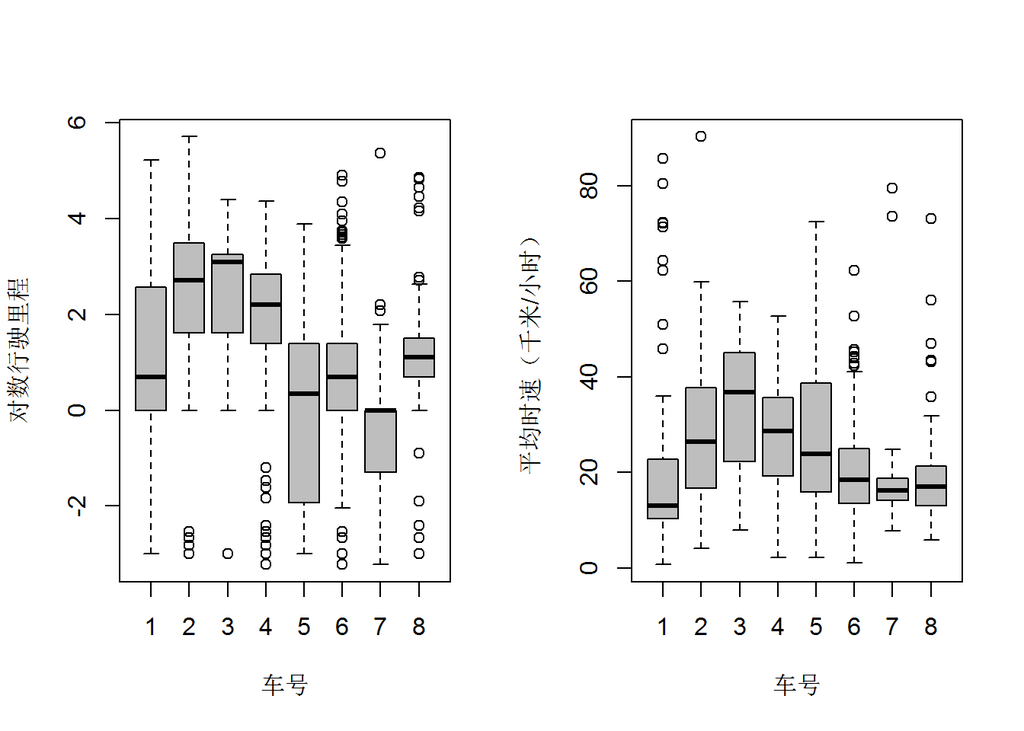

### 任务三 去掉最后一列车号，对剩余的变量做因子分析。假设我们一开始就决定保留4个公因子，你如何解释结果？给每个因子起一个名字。提示：可以利用factpc函数，得到因子分析的结果，这时你需要加载mvstat包。

```
##
##  Factor Analysis for Princomp in Varimax:
```

```
##          Vars Vars.Prop Vars.Cum
## Factor1 3.680    26.286    26.29
## Factor2 3.301    23.582    49.87
## Factor3 2.474    17.671    67.54
## Factor4 1.236     8.828    76.37
```

```
##            Factor1 Factor2 Factor3 Factor4
## 行驶里程     0.394   0.829   0.181   0.048 0.878
## 行驶时长     0.192   0.847   0.289   0.041 0.839
## 平均时速     0.873   0.362   0.226   0.118 0.958
## 时速标准差   0.677   0.392   0.482   0.063 0.849
## 时速最大值   0.653   0.420   0.504   0.047 0.859
## 平稳性       0.473   0.263   0.201  -0.097 0.343
## 转速平均值   0.711   0.178   0.509   0.185 0.830
## 转速标准差   0.273   0.153   0.864   0.092 0.853
## 转速最大值   0.240   0.215   0.858   0.077 0.845
## 早晚高峰    -0.014  -0.092  -0.045  -0.761 0.590
## 深夜出行     0.121  -0.041   0.084   0.746 0.579
## 极度拥堵    -0.886   0.008  -0.094  -0.132 0.811
## 高速行驶     0.424   0.712   0.037  -0.011 0.688
## 疲劳驾驶    -0.015   0.865   0.138   0.038 0.769
```

### 任务四 分别尝试2个、3个、4个和5个公因子。你如何决定保留几个公因子？陈述你的理由。没错精品案例保留了3个公因子，但这不代表精品案例做的就是对的。注意，不要输出一大堆无关结果，选择性的输出支持你的结论的结果。

### 任务五 现在想对所有的行程（注意不是车）进行聚类，聚类的指标是任务三得到的几个因子得分。你如何决定应该聚成几类？请输出每一类的类中心和样本量。解读一下每一类行程分别代表什么样的驾驶习惯。这个任务对于你反思任务三有什么帮助么？提示：这个任务没有标准答案，请给出合情合理的解读。不要胡说八道，先说服你自己。

### 任务六 这个任务有点难度。请根据前几个任务的结果，描述一下这8辆车的驾驶行为。想一想你能用什么统计图来直观地展示你的结果。注意：请你自己认真思考，不要抄袭已有的精品案例的想法。